# 1 Covariance and Correlation

## **Covariance**

Covariance is a measure of how much two random variables vary together. It's similar to variance, but where variance tells you how a *single* variable varies, **co**variance tells you how two variables vary together.  
A positive covariance means that the two variables at hand are postively related, and they move in the same direction.  
A negative covariance means that the two variables are inversely related, or that they move in opposite directions.

[figure not shown]

The formula to calculate covariance is as follows, $$ cov_{x, y} = \frac{ \sum (x_i - \bar{x})(y_i - \bar{y})}{N - 1} $$

```python
import numpy as np

def covariance(x, y):
    '''
    Returns covariance between two array-like objects of numeric values.

    Parameters:

    x: array-like object of numeric values
    y: array-like object of numeric values
    '''
    if len(x) != len(y):
        return

    x_mean = np.mean(x)
    y_mean = np.mean(y)
    sum = 0

    for i in range(len(x)):
        sum += ((x[i] - x_mean) * (y[i] - y_mean))

    return sum / (len(x) - 1)
```

```python
# Generating x and y:
x = np.arange(10)
y = x + np.random.rand(10)    # Adding some noise using rand()
print(f"x: {x}")
print(f"y: {y}")
```

```
x: [0 1 2 3 4 5 6 7 8 9]
y: [0.75748157 1.33266435 2.5820461  3.13766692 4.6475828  5.05373785
 6.43012799 7.23605775 8.26982824 9.96623949]
```

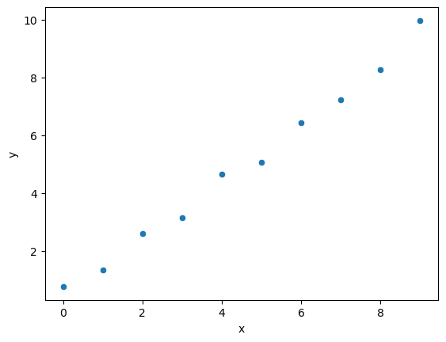

```python
# Let's plot the data
import matplotlib.pyplot as plt
import seaborn as sns
%matplotlib inline

sns.scatterplot(x = x, y = y, palette = "Pastel1")
plt.xlabel("x")
plt.ylabel("y")

plt.show()
```

It's obvious that covariance between x and y must be positive.

```python
print(f"Covariance: {covariance(x, y)}")
```

```
Covariance: 9.166253608051877
```

```python
# Using cov function of numpy to calculate the covariance
print(f"Covariance: {np.cov(x, y)[0][1]}")
```

```
Covariance: 9.166253608051877
```

np.cov() always returns the covariance matrix.

## **Correlation**

Correlation is also a measure of how much two random variables change together. However,

- Covariance only indicates the direction of the linear relationship between variables, whereas correlation measures both strength and direction of the linear relationship between two variables.
- Covariance values are not standardized, whereas correlation values are standardized.

The Pearson product-moment correlation coefficient, also known as $r, \rho$, or Pearson's $r$, is a measure of the strength and direction of the linear relationship between two variables that is defined as the covariance of the variables divided by the product of their standard deviations.

[figure not shown]

The correlation is unitless and always lies between -1 (perfect anti-correlation) and 1 (perfect correlation).
The formula of Pearson's r is as follows, $$ \rho \ (or \ r) = \frac{cov_{x, y}}{\sigma_x \sigma_y} = \frac{ \sum (x_i - \bar{x})(y_i - \bar{y})}{ \sqrt{\sum (x_i - \bar{x})^2 \sum(y_i - \bar{y})^2}} $$

```python
def correlation(x, y):
    '''
    Returns correlation between two array-like objects of numeric values.

    Parameters:

    x: array-like object of numeric values
    y: array-like object of numeric values
    '''
    return np.corrcoef(x, y)[0][1]    # np.corrcoef() always returns the correlation matrix
```

```python
# Using the same data x and y as above
print(f"Correlation: {correlation(x, y)}")
```

```
Correlation: 0.995402722824334
```